# Risk Factor Analysis

## Outcome Variable

**Outcome Variable:** ever_wasted

## Predictor Variables

**Intervention Variable:** nchldlt5

**Adjustment Set:**

- arm
- W_mage
- meducyrs
- feducyrs
- hhwealth_quart
- hfoodsec
- W_mhtcm
- W_nrooms
- W_parity
- impfloor
- impsan
- safeh20
- delta_W_mage
- delta_meducyrs
- delta_feducyrs
- delta_hhwealth_quart
- delta_hfoodsec
- delta_W_mhtcm
- delta_W_nrooms
- delta_W_parity
- delta_impfloor
- delta_impsan
- delta_safeh20

## Stratifying Variables

The analysis was stratified on these variable(s):

- agecat
- studyid
- country

## Data Summary

| agecat | studyid | country | nchldlt5 | ever_wasted | n_cell | n |
| --- | --- | --- | --- | --- | --- | --- |
| 0-24 months | ki1000108-IRC | INDIA | 1 | 0 | 25 | 410 |
| 0-24 months | ki1000108-IRC | INDIA | 1 | 1 | 64 | 410 |
| 0-24 months | ki1000108-IRC | INDIA | 2+ | 0 | 116 | 410 |
| 0-24 months | ki1000108-IRC | INDIA | 2+ | 1 | 205 | 410 |
| 0-24 months | ki1017093b-PROVIDE | BANGLADESH | 1 | 0 | 327 | 700 |
| 0-24 months | ki1017093b-PROVIDE | BANGLADESH | 1 | 1 | 185 | 700 |
| 0-24 months | ki1017093b-PROVIDE | BANGLADESH | 2+ | 0 | 127 | 700 |
| 0-24 months | ki1017093b-PROVIDE | BANGLADESH | 2+ | 1 | 61 | 700 |
| 0-24 months | ki1017093c-NIH-Crypto | BANGLADESH | 1 | 0 | 368 | 758 |
| 0-24 months | ki1017093c-NIH-Crypto | BANGLADESH | 1 | 1 | 173 | 758 |
| 0-24 months | ki1017093c-NIH-Crypto | BANGLADESH | 2+ | 0 | 139 | 758 |
| 0-24 months | ki1017093c-NIH-Crypto | BANGLADESH | 2+ | 1 | 78 | 758 |
| 0-24 months | ki1066203-TanzaniaChild2 | TANZANIA, UNITED REPUBLIC OF | 1 | 0 | 1242 | 2385 |
| 0-24 months | ki1066203-TanzaniaChild2 | TANZANIA, UNITED REPUBLIC OF | 1 | 1 | 395 | 2385 |
| 0-24 months | ki1066203-TanzaniaChild2 | TANZANIA, UNITED REPUBLIC OF | 2+ | 0 | 579 | 2385 |
| 0-24 months | ki1066203-TanzaniaChild2 | TANZANIA, UNITED REPUBLIC OF | 2+ | 1 | 169 | 2385 |
| 0-24 months | ki1112895-iLiNS-Zinc | BURKINA FASO | 1 | 0 | 838 | 3189 |
| 0-24 months | ki1112895-iLiNS-Zinc | BURKINA FASO | 1 | 1 | 235 | 3189 |
| 0-24 months | ki1112895-iLiNS-Zinc | BURKINA FASO | 2+ | 0 | 1624 | 3189 |
| 0-24 months | ki1112895-iLiNS-Zinc | BURKINA FASO | 2+ | 1 | 492 | 3189 |
| 0-24 months | ki1148112-LCNI-5 | MALAWI | 1 | 0 | 366 | 812 |
| 0-24 months | ki1148112-LCNI-5 | MALAWI | 1 | 1 | 25 | 812 |
| 0-24 months | ki1148112-LCNI-5 | MALAWI | 2+ | 0 | 380 | 812 |
| 0-24 months | ki1148112-LCNI-5 | MALAWI | 2+ | 1 | 41 | 812 |
| 0-24 months | kiGH5241-JiVitA-3 | BANGLADESH | 1 | 0 | 12740 | 26933 |
| 0-24 months | kiGH5241-JiVitA-3 | BANGLADESH | 1 | 1 | 4486 | 26933 |
| 0-24 months | kiGH5241-JiVitA-3 | BANGLADESH | 2+ | 0 | 7242 | 26933 |
| 0-24 months | kiGH5241-JiVitA-3 | BANGLADESH | 2+ | 1 | 2465 | 26933 |
| 0-6 months | ki1000108-IRC | INDIA | 1 | 0 | 37 | 410 |
| 0-6 months | ki1000108-IRC | INDIA | 1 | 1 | 52 | 410 |
| 0-6 months | ki1000108-IRC | INDIA | 2+ | 0 | 150 | 410 |
| 0-6 months | ki1000108-IRC | INDIA | 2+ | 1 | 171 | 410 |
| 0-6 months | ki1017093b-PROVIDE | BANGLADESH | 1 | 0 | 375 | 700 |
| 0-6 months | ki1017093b-PROVIDE | BANGLADESH | 1 | 1 | 137 | 700 |
| 0-6 months | ki1017093b-PROVIDE | BANGLADESH | 2+ | 0 | 144 | 700 |
| 0-6 months | ki1017093b-PROVIDE | BANGLADESH | 2+ | 1 | 44 | 700 |
| 0-6 months | ki1017093c-NIH-Crypto | BANGLADESH | 1 | 0 | 404 | 758 |
| 0-6 months | ki1017093c-NIH-Crypto | BANGLADESH | 1 | 1 | 137 | 758 |
| 0-6 months | ki1017093c-NIH-Crypto | BANGLADESH | 2+ | 0 | 158 | 758 |
| 0-6 months | ki1017093c-NIH-Crypto | BANGLADESH | 2+ | 1 | 59 | 758 |
| 0-6 months | ki1066203-TanzaniaChild2 | TANZANIA, UNITED REPUBLIC OF | 1 | 0 | 1407 | 2385 |
| 0-6 months | ki1066203-TanzaniaChild2 | TANZANIA, UNITED REPUBLIC OF | 1 | 1 | 230 | 2385 |
| 0-6 months | ki1066203-TanzaniaChild2 | TANZANIA, UNITED REPUBLIC OF | 2+ | 0 | 646 | 2385 |
| 0-6 months | ki1066203-TanzaniaChild2 | TANZANIA, UNITED REPUBLIC OF | 2+ | 1 | 102 | 2385 |
| 0-6 months | ki1148112-LCNI-5 | MALAWI | 1 | 0 | 121 | 267 |
| 0-6 months | ki1148112-LCNI-5 | MALAWI | 1 | 1 | 1 | 267 |
| 0-6 months | ki1148112-LCNI-5 | MALAWI | 2+ | 0 | 142 | 267 |
| 0-6 months | ki1148112-LCNI-5 | MALAWI | 2+ | 1 | 3 | 267 |
| 0-6 months | kiGH5241-JiVitA-3 | BANGLADESH | 1 | 0 | 14046 | 26836 |
| 0-6 months | kiGH5241-JiVitA-3 | BANGLADESH | 1 | 1 | 3101 | 26836 |
| 0-6 months | kiGH5241-JiVitA-3 | BANGLADESH | 2+ | 0 | 8058 | 26836 |
| 0-6 months | kiGH5241-JiVitA-3 | BANGLADESH | 2+ | 1 | 1631 | 26836 |
| 6-24 months | ki1000108-IRC | INDIA | 1 | 0 | 56 | 410 |
| 6-24 months | ki1000108-IRC | INDIA | 1 | 1 | 33 | 410 |
| 6-24 months | ki1000108-IRC | INDIA | 2+ | 0 | 227 | 410 |
| 6-24 months | ki1000108-IRC | INDIA | 2+ | 1 | 94 | 410 |
| 6-24 months | ki1017093b-PROVIDE | BANGLADESH | 1 | 0 | 380 | 615 |
| 6-24 months | ki1017093b-PROVIDE | BANGLADESH | 1 | 1 | 68 | 615 |
| 6-24 months | ki1017093b-PROVIDE | BANGLADESH | 2+ | 0 | 136 | 615 |
| 6-24 months | ki1017093b-PROVIDE | BANGLADESH | 2+ | 1 | 31 | 615 |
| 6-24 months | ki1017093c-NIH-Crypto | BANGLADESH | 1 | 0 | 460 | 730 |
| 6-24 months | ki1017093c-NIH-Crypto | BANGLADESH | 1 | 1 | 60 | 730 |
| 6-24 months | ki1017093c-NIH-Crypto | BANGLADESH | 2+ | 0 | 174 | 730 |
| 6-24 months | ki1017093c-NIH-Crypto | BANGLADESH | 2+ | 1 | 36 | 730 |
| 6-24 months | ki1066203-TanzaniaChild2 | TANZANIA, UNITED REPUBLIC OF | 1 | 0 | 1154 | 2010 |
| 6-24 months | ki1066203-TanzaniaChild2 | TANZANIA, UNITED REPUBLIC OF | 1 | 1 | 229 | 2010 |
| 6-24 months | ki1066203-TanzaniaChild2 | TANZANIA, UNITED REPUBLIC OF | 2+ | 0 | 533 | 2010 |
| 6-24 months | ki1066203-TanzaniaChild2 | TANZANIA, UNITED REPUBLIC OF | 2+ | 1 | 94 | 2010 |
| 6-24 months | ki1112895-iLiNS-Zinc | BURKINA FASO | 1 | 0 | 838 | 3189 |
| 6-24 months | ki1112895-iLiNS-Zinc | BURKINA FASO | 1 | 1 | 235 | 3189 |
| 6-24 months | ki1112895-iLiNS-Zinc | BURKINA FASO | 2+ | 0 | 1624 | 3189 |
| 6-24 months | ki1112895-iLiNS-Zinc | BURKINA FASO | 2+ | 1 | 492 | 3189 |
| 6-24 months | ki1148112-LCNI-5 | MALAWI | 1 | 0 | 360 | 800 |
| 6-24 months | ki1148112-LCNI-5 | MALAWI | 1 | 1 | 24 | 800 |
| 6-24 months | ki1148112-LCNI-5 | MALAWI | 2+ | 0 | 377 | 800 |
| 6-24 months | ki1148112-LCNI-5 | MALAWI | 2+ | 1 | 39 | 800 |
| 6-24 months | kiGH5241-JiVitA-3 | BANGLADESH | 1 | 0 | 9417 | 17286 |
| 6-24 months | kiGH5241-JiVitA-3 | BANGLADESH | 1 | 1 | 1787 | 17286 |
| 6-24 months | kiGH5241-JiVitA-3 | BANGLADESH | 2+ | 0 | 5037 | 17286 |
| 6-24 months | kiGH5241-JiVitA-3 | BANGLADESH | 2+ | 1 | 1045 | 17286 |

The following strata were considered:

- agecat: 0-24 months, studyid: ki1000108-IRC, country: INDIA
- agecat: 0-24 months, studyid: ki1017093b-PROVIDE, country: BANGLADESH
- agecat: 0-24 months, studyid: ki1017093c-NIH-Crypto, country: BANGLADESH
- agecat: 0-24 months, studyid: ki1066203-TanzaniaChild2, country: TANZANIA, UNITED REPUBLIC OF
- agecat: 0-24 months, studyid: ki1112895-iLiNS-Zinc, country: BURKINA FASO
- agecat: 0-24 months, studyid: ki1148112-LCNI-5, country: MALAWI
- agecat: 0-24 months, studyid: kiGH5241-JiVitA-3, country: BANGLADESH
- agecat: 0-6 months, studyid: ki1000108-IRC, country: INDIA
- agecat: 0-6 months, studyid: ki1017093b-PROVIDE, country: BANGLADESH
- agecat: 0-6 months, studyid: ki1017093c-NIH-Crypto, country: BANGLADESH
- agecat: 0-6 months, studyid: ki1066203-TanzaniaChild2, country: TANZANIA, UNITED REPUBLIC OF
- agecat: 0-6 months, studyid: ki1148112-LCNI-5, country: MALAWI
- agecat: 0-6 months, studyid: kiGH5241-JiVitA-3, country: BANGLADESH
- agecat: 6-24 months, studyid: ki1000108-IRC, country: INDIA
- agecat: 6-24 months, studyid: ki1017093b-PROVIDE, country: BANGLADESH
- agecat: 6-24 months, studyid: ki1017093c-NIH-Crypto, country: BANGLADESH
- agecat: 6-24 months, studyid: ki1066203-TanzaniaChild2, country: TANZANIA, UNITED REPUBLIC OF
- agecat: 6-24 months, studyid: ki1112895-iLiNS-Zinc, country: BURKINA FASO
- agecat: 6-24 months, studyid: ki1148112-LCNI-5, country: MALAWI
- agecat: 6-24 months, studyid: kiGH5241-JiVitA-3, country: BANGLADESH

### Dropped Strata

Some strata were dropped due to rare outcomes:

- agecat: 0-6 months, studyid: ki1148112-LCNI-5, country: MALAWI

## Methods Detail

We’re interested in the causal parameters $E[Y_a]$ for all values of $a \in \mathcal{A}$. These parameters represent the mean outcome if, possibly contrary to fact, we intervened to set all units to have $A=a$. Under the randomization and positivity assumptions, these are identified by the statistical parameters $\psi_a=E_W[E_{Y|A,W}(Y|A=a,W)]$. In addition, we’re interested in the mean of $Y$, $E[Y]$ under no intervention (the observed mean). We will estimate these parameters by using SuperLearner to fit the relevant likelihood factors – $E_{Y|A,W}(Y|A=a,W)$ and $p(A=a|W)$, and then updating our likelihood fit using a joint TMLE.

For unadjusted analyses ($W=\{\}$), initial likelihoods were estimated using Lrnr_glm to estimate the simple $E(Y|A)$ and Lrnr_mean to estimate $p(A)$. For adjusted analyses, a small library containing Lrnr_glmnet, Lrnr_xgboost, and Lrnr_mean was used.

Having estimated these parameters, we will then use the delta method to estimate relative risks and attributable risks relative to a prespecified baseline level of $A$.

# Results Detail

## Results Plots

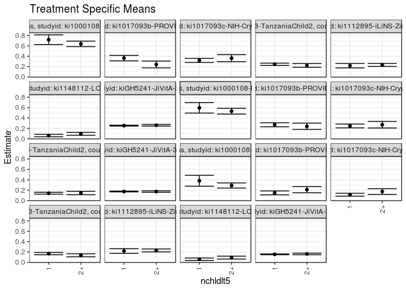

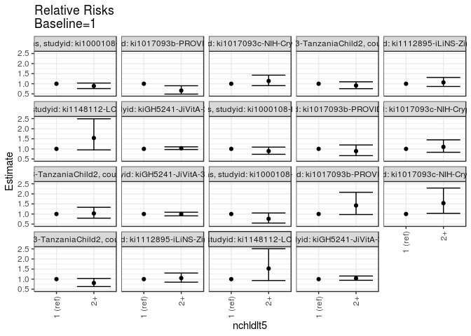

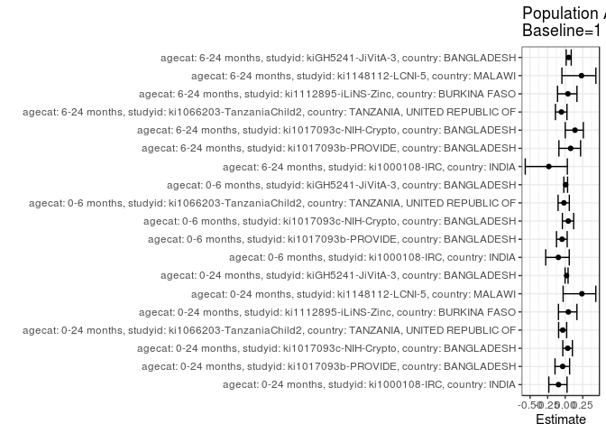

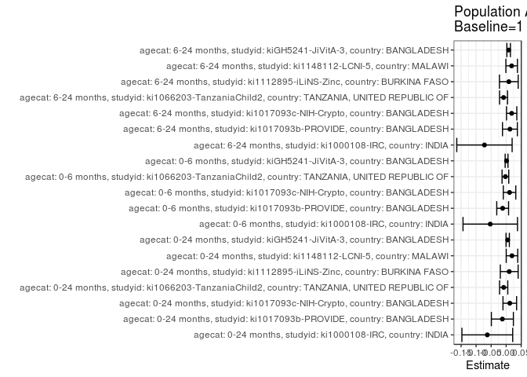

## Results Table

### Parameter: TSM

| agecat | studyid | country | intervention_level | baseline_level | estimate | ci_lower | ci_upper |
| --- | --- | --- | --- | --- | --- | --- | --- |
| 0-24 months | ki1000108-IRC | INDIA | 1 | NA | 0.7188713 | 0.6251096 | 0.8126331 |
| 0-24 months | ki1000108-IRC | INDIA | 2+ | NA | 0.6378058 | 0.5851055 | 0.6905060 |
| 0-24 months | ki1017093b-PROVIDE | BANGLADESH | 1 | NA | 0.3640592 | 0.3112233 | 0.4168952 |
| 0-24 months | ki1017093b-PROVIDE | BANGLADESH | 2+ | NA | 0.2407730 | 0.1751330 | 0.3064129 |
| 0-24 months | ki1017093c-NIH-Crypto | BANGLADESH | 1 | NA | 0.3190655 | 0.2791039 | 0.3590272 |
| 0-24 months | ki1017093c-NIH-Crypto | BANGLADESH | 2+ | NA | 0.3627570 | 0.2944146 | 0.4310995 |
| 0-24 months | ki1066203-TanzaniaChild2 | TANZANIA, UNITED REPUBLIC OF | 1 | NA | 0.2447018 | 0.2224219 | 0.2669816 |
| 0-24 months | ki1066203-TanzaniaChild2 | TANZANIA, UNITED REPUBLIC OF | 2+ | NA | 0.2227655 | 0.1866560 | 0.2588751 |
| 0-24 months | ki1112895-iLiNS-Zinc | BURKINA FASO | 1 | NA | 0.2177941 | 0.1747726 | 0.2608157 |
| 0-24 months | ki1112895-iLiNS-Zinc | BURKINA FASO | 2+ | NA | 0.2324163 | 0.2039727 | 0.2608598 |
| 0-24 months | ki1148112-LCNI-5 | MALAWI | 1 | NA | 0.0619513 | 0.0383159 | 0.0855866 |
| 0-24 months | ki1148112-LCNI-5 | MALAWI | 2+ | NA | 0.0953586 | 0.0673931 | 0.1233242 |
| 0-24 months | kiGH5241-JiVitA-3 | BANGLADESH | 1 | NA | 0.2529621 | 0.2445897 | 0.2613345 |
| 0-24 months | kiGH5241-JiVitA-3 | BANGLADESH | 2+ | NA | 0.2608373 | 0.2451515 | 0.2765232 |
| 0-6 months | ki1000108-IRC | INDIA | 1 | NA | 0.5968527 | 0.4953293 | 0.6983761 |
| 0-6 months | ki1000108-IRC | INDIA | 2+ | NA | 0.5319719 | 0.4770900 | 0.5868537 |
| 0-6 months | ki1017093b-PROVIDE | BANGLADESH | 1 | NA | 0.2702253 | 0.2315996 | 0.3088510 |
| 0-6 months | ki1017093b-PROVIDE | BANGLADESH | 2+ | NA | 0.2404154 | 0.1788121 | 0.3020186 |
| 0-6 months | ki1017093c-NIH-Crypto | BANGLADESH | 1 | NA | 0.2473005 | 0.2105575 | 0.2840434 |
| 0-6 months | ki1017093c-NIH-Crypto | BANGLADESH | 2+ | NA | 0.2712206 | 0.2077621 | 0.3346790 |
| 0-6 months | ki1066203-TanzaniaChild2 | TANZANIA, UNITED REPUBLIC OF | 1 | NA | 0.1417350 | 0.1236379 | 0.1598321 |
| 0-6 months | ki1066203-TanzaniaChild2 | TANZANIA, UNITED REPUBLIC OF | 2+ | NA | 0.1457446 | 0.1128106 | 0.1786785 |
| 0-6 months | kiGH5241-JiVitA-3 | BANGLADESH | 1 | NA | 0.1750183 | 0.1675464 | 0.1824901 |
| 0-6 months | kiGH5241-JiVitA-3 | BANGLADESH | 2+ | NA | 0.1738969 | 0.1593721 | 0.1884217 |
| 6-24 months | ki1000108-IRC | INDIA | 1 | NA | 0.3820143 | 0.2770033 | 0.4870254 |
| 6-24 months | ki1000108-IRC | INDIA | 2+ | NA | 0.2909345 | 0.2412467 | 0.3406223 |
| 6-24 months | ki1017093b-PROVIDE | BANGLADESH | 1 | NA | 0.1484687 | 0.1108881 | 0.1860492 |
| 6-24 months | ki1017093b-PROVIDE | BANGLADESH | 2+ | NA | 0.2111438 | 0.1508469 | 0.2714406 |
| 6-24 months | ki1017093c-NIH-Crypto | BANGLADESH | 1 | NA | 0.1131840 | 0.0856899 | 0.1406781 |
| 6-24 months | ki1017093c-NIH-Crypto | BANGLADESH | 2+ | NA | 0.1740854 | 0.1193576 | 0.2288132 |
| 6-24 months | ki1066203-TanzaniaChild2 | TANZANIA, UNITED REPUBLIC OF | 1 | NA | 0.1693372 | 0.1477454 | 0.1909290 |
| 6-24 months | ki1066203-TanzaniaChild2 | TANZANIA, UNITED REPUBLIC OF | 2+ | NA | 0.1368027 | 0.1077766 | 0.1658288 |
| 6-24 months | ki1112895-iLiNS-Zinc | BURKINA FASO | 1 | NA | 0.2190846 | 0.1739517 | 0.2642176 |
| 6-24 months | ki1112895-iLiNS-Zinc | BURKINA FASO | 2+ | NA | 0.2303334 | 0.2023536 | 0.2583133 |
| 6-24 months | ki1148112-LCNI-5 | MALAWI | 1 | NA | 0.0604590 | 0.0367087 | 0.0842093 |
| 6-24 months | ki1148112-LCNI-5 | MALAWI | 2+ | NA | 0.0923284 | 0.0644130 | 0.1202438 |
| 6-24 months | kiGH5241-JiVitA-3 | BANGLADESH | 1 | NA | 0.1555316 | 0.1473416 | 0.1637217 |
| 6-24 months | kiGH5241-JiVitA-3 | BANGLADESH | 2+ | NA | 0.1621690 | 0.1474723 | 0.1768657 |

### Parameter: E(Y)

| agecat | studyid | country | intervention_level | baseline_level | estimate | ci_lower | ci_upper |
| --- | --- | --- | --- | --- | --- | --- | --- |
| 0-24 months | ki1000108-IRC | INDIA | NA | NA | 0.6560976 | 0.6100625 | 0.7021326 |
| 0-24 months | ki1017093b-PROVIDE | BANGLADESH | NA | NA | 0.3514286 | 0.3160364 | 0.3868207 |
| 0-24 months | ki1017093c-NIH-Crypto | BANGLADESH | NA | NA | 0.3311346 | 0.2976093 | 0.3646598 |
| 0-24 months | ki1066203-TanzaniaChild2 | TANZANIA, UNITED REPUBLIC OF | NA | NA | 0.2364780 | 0.2194210 | 0.2535349 |
| 0-24 months | ki1112895-iLiNS-Zinc | BURKINA FASO | NA | NA | 0.2279712 | 0.2010014 | 0.2549409 |
| 0-24 months | ki1148112-LCNI-5 | MALAWI | NA | NA | 0.0812808 | 0.0624736 | 0.1000879 |
| 0-24 months | kiGH5241-JiVitA-3 | BANGLADESH | NA | NA | 0.2580849 | 0.2516205 | 0.2645492 |
| 0-6 months | ki1000108-IRC | INDIA | NA | NA | 0.5439024 | 0.4956326 | 0.5921723 |
| 0-6 months | ki1017093b-PROVIDE | BANGLADESH | NA | NA | 0.2585714 | 0.2261125 | 0.2910304 |
| 0-6 months | ki1017093c-NIH-Crypto | BANGLADESH | NA | NA | 0.2585752 | 0.2273844 | 0.2897660 |
| 0-6 months | ki1066203-TanzaniaChild2 | TANZANIA, UNITED REPUBLIC OF | NA | NA | 0.1392034 | 0.1253080 | 0.1530987 |
| 0-6 months | kiGH5241-JiVitA-3 | BANGLADESH | NA | NA | 0.1763303 | 0.1707026 | 0.1819580 |
| 6-24 months | ki1000108-IRC | INDIA | NA | NA | 0.3097561 | 0.2649438 | 0.3545684 |
| 6-24 months | ki1017093b-PROVIDE | BANGLADESH | NA | NA | 0.1609756 | 0.1319065 | 0.1900447 |
| 6-24 months | ki1017093c-NIH-Crypto | BANGLADESH | NA | NA | 0.1315068 | 0.1069744 | 0.1560393 |
| 6-24 months | ki1066203-TanzaniaChild2 | TANZANIA, UNITED REPUBLIC OF | NA | NA | 0.1606965 | 0.1446374 | 0.1767556 |
| 6-24 months | ki1112895-iLiNS-Zinc | BURKINA FASO | NA | NA | 0.2279712 | 0.2010014 | 0.2549409 |
| 6-24 months | ki1148112-LCNI-5 | MALAWI | NA | NA | 0.0787500 | 0.0600738 | 0.0974262 |
| 6-24 months | kiGH5241-JiVitA-3 | BANGLADESH | NA | NA | 0.1638320 | 0.1577093 | 0.1699547 |

### Parameter: RR

| agecat | studyid | country | intervention_level | baseline_level | estimate | ci_lower | ci_upper |
| --- | --- | --- | --- | --- | --- | --- | --- |
| 0-24 months | ki1000108-IRC | INDIA | 1 | 1 | 1.0000000 | 1.0000000 | 1.0000000 |
| 0-24 months | ki1000108-IRC | INDIA | 2+ | 1 | 0.8872322 | 0.7601049 | 1.0356214 |
| 0-24 months | ki1017093b-PROVIDE | BANGLADESH | 1 | 1 | 1.0000000 | 1.0000000 | 1.0000000 |
| 0-24 months | ki1017093b-PROVIDE | BANGLADESH | 2+ | 1 | 0.6613566 | 0.4856015 | 0.9007231 |
| 0-24 months | ki1017093c-NIH-Crypto | BANGLADESH | 1 | 1 | 1.0000000 | 1.0000000 | 1.0000000 |
| 0-24 months | ki1017093c-NIH-Crypto | BANGLADESH | 2+ | 1 | 1.1369359 | 0.9066789 | 1.4256681 |
| 0-24 months | ki1066203-TanzaniaChild2 | TANZANIA, UNITED REPUBLIC OF | 1 | 1 | 1.0000000 | 1.0000000 | 1.0000000 |
| 0-24 months | ki1066203-TanzaniaChild2 | TANZANIA, UNITED REPUBLIC OF | 2+ | 1 | 0.9103552 | 0.7559658 | 1.0962751 |
| 0-24 months | ki1112895-iLiNS-Zinc | BURKINA FASO | 1 | 1 | 1.0000000 | 1.0000000 | 1.0000000 |
| 0-24 months | ki1112895-iLiNS-Zinc | BURKINA FASO | 2+ | 1 | 1.0671374 | 0.8664537 | 1.3143024 |
| 0-24 months | ki1148112-LCNI-5 | MALAWI | 1 | 1 | 1.0000000 | 1.0000000 | 1.0000000 |
| 0-24 months | ki1148112-LCNI-5 | MALAWI | 2+ | 1 | 1.5392526 | 0.9504598 | 2.4927919 |
| 0-24 months | kiGH5241-JiVitA-3 | BANGLADESH | 1 | 1 | 1.0000000 | 1.0000000 | 1.0000000 |
| 0-24 months | kiGH5241-JiVitA-3 | BANGLADESH | 2+ | 1 | 1.0311319 | 0.9660130 | 1.1006405 |
| 0-6 months | ki1000108-IRC | INDIA | 1 | 1 | 1.0000000 | 1.0000000 | 1.0000000 |
| 0-6 months | ki1000108-IRC | INDIA | 2+ | 1 | 0.8912951 | 0.7303846 | 1.0876556 |
| 0-6 months | ki1017093b-PROVIDE | BANGLADESH | 1 | 1 | 1.0000000 | 1.0000000 | 1.0000000 |
| 0-6 months | ki1017093b-PROVIDE | BANGLADESH | 2+ | 1 | 0.8896848 | 0.6628195 | 1.1942001 |
| 0-6 months | ki1017093c-NIH-Crypto | BANGLADESH | 1 | 1 | 1.0000000 | 1.0000000 | 1.0000000 |
| 0-6 months | ki1017093c-NIH-Crypto | BANGLADESH | 2+ | 1 | 1.0967248 | 0.8309600 | 1.4474889 |
| 0-6 months | ki1066203-TanzaniaChild2 | TANZANIA, UNITED REPUBLIC OF | 1 | 1 | 1.0000000 | 1.0000000 | 1.0000000 |
| 0-6 months | ki1066203-TanzaniaChild2 | TANZANIA, UNITED REPUBLIC OF | 2+ | 1 | 1.0282891 | 0.7931637 | 1.3331150 |
| 0-6 months | kiGH5241-JiVitA-3 | BANGLADESH | 1 | 1 | 1.0000000 | 1.0000000 | 1.0000000 |
| 0-6 months | kiGH5241-JiVitA-3 | BANGLADESH | 2+ | 1 | 0.9935929 | 0.9075382 | 1.0878074 |
| 6-24 months | ki1000108-IRC | INDIA | 1 | 1 | 1.0000000 | 1.0000000 | 1.0000000 |
| 6-24 months | ki1000108-IRC | INDIA | 2+ | 1 | 0.7615801 | 0.5515106 | 1.0516647 |
| 6-24 months | ki1017093b-PROVIDE | BANGLADESH | 1 | 1 | 1.0000000 | 1.0000000 | 1.0000000 |
| 6-24 months | ki1017093b-PROVIDE | BANGLADESH | 2+ | 1 | 1.4221434 | 0.9727956 | 2.0790511 |
| 6-24 months | ki1017093c-NIH-Crypto | BANGLADESH | 1 | 1 | 1.0000000 | 1.0000000 | 1.0000000 |
| 6-24 months | ki1017093c-NIH-Crypto | BANGLADESH | 2+ | 1 | 1.5380743 | 1.0340462 | 2.2877822 |
| 6-24 months | ki1066203-TanzaniaChild2 | TANZANIA, UNITED REPUBLIC OF | 1 | 1 | 1.0000000 | 1.0000000 | 1.0000000 |
| 6-24 months | ki1066203-TanzaniaChild2 | TANZANIA, UNITED REPUBLIC OF | 2+ | 1 | 0.8078713 | 0.6308184 | 1.0346178 |
| 6-24 months | ki1112895-iLiNS-Zinc | BURKINA FASO | 1 | 1 | 1.0000000 | 1.0000000 | 1.0000000 |
| 6-24 months | ki1112895-iLiNS-Zinc | BURKINA FASO | 2+ | 1 | 1.0513444 | 0.8483258 | 1.3029489 |
| 6-24 months | ki1148112-LCNI-5 | MALAWI | 1 | 1 | 1.0000000 | 1.0000000 | 1.0000000 |
| 6-24 months | ki1148112-LCNI-5 | MALAWI | 2+ | 1 | 1.5271228 | 0.9296475 | 2.5085896 |
| 6-24 months | kiGH5241-JiVitA-3 | BANGLADESH | 1 | 1 | 1.0000000 | 1.0000000 | 1.0000000 |
| 6-24 months | kiGH5241-JiVitA-3 | BANGLADESH | 2+ | 1 | 1.0426751 | 0.9416355 | 1.1545564 |

### Parameter: PAR

| agecat | studyid | country | intervention_level | baseline_level | estimate | ci_lower | ci_upper |
| --- | --- | --- | --- | --- | --- | --- | --- |
| 0-24 months | ki1000108-IRC | INDIA | 1 | NA | -0.0627738 | -0.1472824 | 0.0217349 |
| 0-24 months | ki1017093b-PROVIDE | BANGLADESH | 1 | NA | -0.0126307 | -0.0492510 | 0.0239897 |
| 0-24 months | ki1017093c-NIH-Crypto | BANGLADESH | 1 | NA | 0.0120691 | -0.0106026 | 0.0347407 |
| 0-24 months | ki1066203-TanzaniaChild2 | TANZANIA, UNITED REPUBLIC OF | 1 | NA | -0.0082238 | -0.0218055 | 0.0053579 |
| 0-24 months | ki1112895-iLiNS-Zinc | BURKINA FASO | 1 | NA | 0.0101770 | -0.0194905 | 0.0398445 |
| 0-24 months | ki1148112-LCNI-5 | MALAWI | 1 | NA | 0.0193295 | 0.0001970 | 0.0384620 |
| 0-24 months | kiGH5241-JiVitA-3 | BANGLADESH | 1 | NA | 0.0051228 | -0.0003675 | 0.0106130 |
| 0-6 months | ki1000108-IRC | INDIA | 1 | NA | -0.0529502 | -0.1435708 | 0.0376703 |
| 0-6 months | ki1017093b-PROVIDE | BANGLADESH | 1 | NA | -0.0116539 | -0.0313252 | 0.0080174 |
| 0-6 months | ki1017093c-NIH-Crypto | BANGLADESH | 1 | NA | 0.0112747 | -0.0094753 | 0.0320247 |
| 0-6 months | ki1066203-TanzaniaChild2 | TANZANIA, UNITED REPUBLIC OF | 1 | NA | -0.0025316 | -0.0136602 | 0.0085969 |
| 0-6 months | kiGH5241-JiVitA-3 | BANGLADESH | 1 | NA | 0.0013120 | -0.0034324 | 0.0060564 |
| 6-24 months | ki1000108-IRC | INDIA | 1 | NA | -0.0722583 | -0.1643643 | 0.0198478 |
| 6-24 months | ki1017093b-PROVIDE | BANGLADESH | 1 | NA | 0.0125069 | -0.0121968 | 0.0372107 |
| 6-24 months | ki1017093c-NIH-Crypto | BANGLADESH | 1 | NA | 0.0183229 | 0.0012274 | 0.0354184 |
| 6-24 months | ki1066203-TanzaniaChild2 | TANZANIA, UNITED REPUBLIC OF | 1 | NA | -0.0086407 | -0.0218695 | 0.0045881 |
| 6-24 months | ki1112895-iLiNS-Zinc | BURKINA FASO | 1 | NA | 0.0088865 | -0.0222740 | 0.0400470 |
| 6-24 months | ki1148112-LCNI-5 | MALAWI | 1 | NA | 0.0182910 | -0.0009114 | 0.0374934 |
| 6-24 months | kiGH5241-JiVitA-3 | BANGLADESH | 1 | NA | 0.0083004 | 0.0024526 | 0.0141481 |

### Parameter: PAF

| agecat | studyid | country | intervention_level | baseline_level | estimate | ci_lower | ci_upper |
| --- | --- | --- | --- | --- | --- | --- | --- |
| 0-24 months | ki1000108-IRC | INDIA | 1 | NA | -0.0956775 | -0.2330104 | 0.0263592 |
| 0-24 months | ki1017093b-PROVIDE | BANGLADESH | 1 | NA | -0.0359409 | -0.1453300 | 0.0630006 |
| 0-24 months | ki1017093c-NIH-Crypto | BANGLADESH | 1 | NA | 0.0364476 | -0.0345100 | 0.1025382 |
| 0-24 months | ki1066203-TanzaniaChild2 | TANZANIA, UNITED REPUBLIC OF | 1 | NA | -0.0347762 | -0.0937708 | 0.0210365 |
| 0-24 months | ki1112895-iLiNS-Zinc | BURKINA FASO | 1 | NA | 0.0446417 | -0.0958154 | 0.1670956 |
| 0-24 months | ki1148112-LCNI-5 | MALAWI | 1 | NA | 0.2378117 | -0.0298824 | 0.4359250 |
| 0-24 months | kiGH5241-JiVitA-3 | BANGLADESH | 1 | NA | 0.0198491 | -0.0016492 | 0.0408861 |
| 0-6 months | ki1000108-IRC | INDIA | 1 | NA | -0.0973525 | -0.2778082 | 0.0576188 |
| 0-6 months | ki1017093b-PROVIDE | BANGLADESH | 1 | NA | -0.0450703 | -0.1239658 | 0.0282872 |
| 0-6 months | ki1017093c-NIH-Crypto | BANGLADESH | 1 | NA | 0.0436033 | -0.0400585 | 0.1205354 |
| 0-6 months | ki1066203-TanzaniaChild2 | TANZANIA, UNITED REPUBLIC OF | 1 | NA | -0.0181867 | -0.1013084 | 0.0586614 |
| 0-6 months | kiGH5241-JiVitA-3 | BANGLADESH | 1 | NA | 0.0074407 | -0.0198424 | 0.0339939 |
| 6-24 months | ki1000108-IRC | INDIA | 1 | NA | -0.2332747 | -0.5691848 | 0.0307283 |
| 6-24 months | ki1017093b-PROVIDE | BANGLADESH | 1 | NA | 0.0776945 | -0.0895354 | 0.2192567 |
| 6-24 months | ki1017093c-NIH-Crypto | BANGLADESH | 1 | NA | 0.1393301 | 0.0009706 | 0.2585276 |
| 6-24 months | ki1066203-TanzaniaChild2 | TANZANIA, UNITED REPUBLIC OF | 1 | NA | -0.0537704 | -0.1391269 | 0.0251902 |
| 6-24 months | ki1112895-iLiNS-Zinc | BURKINA FASO | 1 | NA | 0.0389808 | -0.1090605 | 0.1672611 |
| 6-24 months | ki1148112-LCNI-5 | MALAWI | 1 | NA | 0.2322662 | -0.0470396 | 0.4370650 |
| 6-24 months | kiGH5241-JiVitA-3 | BANGLADESH | 1 | NA | 0.0506639 | 0.0143651 | 0.0856259 |